# Package ‘batchtools’

07.09.2018

# The ‘batchtools’-package and its usage in IDE+A

## What does the package do?

Let’s say you have

- algorithms (a1,a2, …,an)
- settings (s1, …)

You want to test and compare them on some functions:

- functions (f1, …)

The ‘batchtools’ package can do that in a nicely organised way and fully automatic.

You want to do it **automatically on a cluster**? Even better.

### Example

```r
## Only for this demo, deletes all Experiments for a fresh strart in the presentation
unlink("~/someTestDir/Experiments/Seminar/", recursive = TRUE)

require(ideaBatch)
source(paste0(system.file(package = "ideaBatch"),"/sources.R"))

## Create an Experiment Registry with a Dir-Name and a Sub-Directory for each test.
reg <- ideaMakeRegistry("Seminar","Test1")

## Add Objective Functions
addProblem("Rosen2D", of_smoofByName("Rosenbrock",2))
addProblem("Rastr2D", of_smoofByName("Rastrigin",2))

## Add Algorithms
addAlgorithm("optimLHD", algorithm_SpotOptimByName("optimLHD", c(-5,-5),c(5,5),
                                                  control = list(funEvals = 100)))
addAlgorithm("cmaesCMAES",algorithm_CMAES(c(-5,-5),c(5,5), control = list("maxit" = 100)))

## Build Experiments
addExperiments(repls = 10)
```

### Show a summary - which Experiments are run?

```r
summarizeExperiments()
```

```
##    problem  algorithm .count
## 1: Rosen2D   optimLHD     10
## 2: Rosen2D cmaesCMAES     10
## 3: Rastr2D   optimLHD     10
## 4: Rastr2D cmaesCMAES     10
```

### Run your experiments

```r
# ideaSubmitJobs()
# ideaSubmitJobs(ids = findNotSubmitted())
#
#ideaSubmitJobs(ids= findExperiments())
submitJobs()
```

The submitJobs command submits Experiments to the cluster. It is possible to submit all defined Experiments, only specific ones, or filter for a certain group of experiments like: notSubmitted, notFinished, notStarted, aborted etc.

### Results

Experiment results will be nicely kept. As they share the same structure every time, general postprocessing functions can be defined and reused / shared in the team.

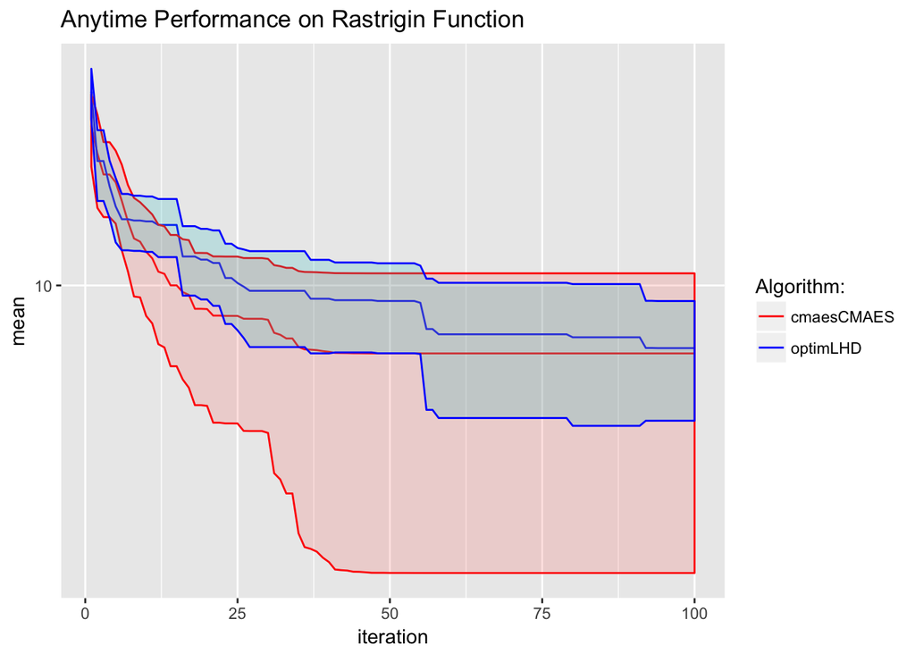

```r
results <- reduceResultsList()
df <- generateResultDF(results)
g <- anyTimePerformancePlot(df[which(df$problemName == "Rastr2D"),],ylog = T, useMinMax = T)
print(g + ggtitle("Anytime Performance on Rastrigin Function"))
```

### Redo / Adapt Experiments

It’s also very easy to rerun old experiments or change them:

```r
submitJobs(id = findJobs()) ## Rerun all experiments, independent of their status
```

```r
addAlgorithm("optimDE", algorithm_SpotOptimByName("optimDE", c(-5,-5),c(5,5),
                                                  control = list(funEvals = 100)))

addExperiments(repls = 20)

summarizeExperiments()
```

```
##    problem  algorithm .count
## 1: Rosen2D   optimLHD     20
## 2: Rosen2D cmaesCMAES     20
## 3: Rastr2D   optimLHD     20
## 4: Rastr2D cmaesCMAES     20
## 5: Rosen2D    optimDE     20
## 6: Rastr2D    optimDE     20
```

```r
submitJobs() ## Only runs the experiments which havent already been done
```

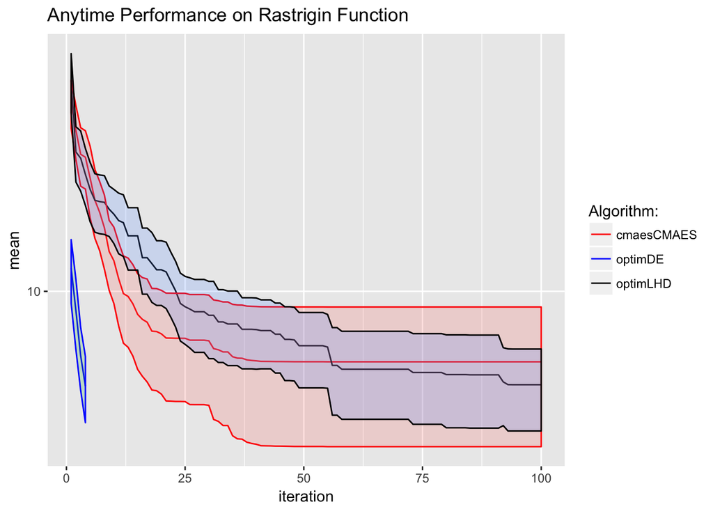

```r
results <- reduceResultsList()
df <- generateResultDF(results)
g <- anyTimePerformancePlot(df[which(df$problemName == "Rastr2D"),],ylog = T, useMinMax = T)
print(g + ggtitle("Anytime Performance on Rastrigin Function"))
```

## Pros/Cons

- +Easy task submission on the cluster
- +Define Algorithms / Objective functions etc. only once, then they can be nicely shared in the same strucutre
- +Same for Postprocessing etc.
- -Initial Setup

## Automatic Installer

- Github package ideaBatch
- devtools::install_github(“frehbach/ideaBatch”)